# R tutorial

Alexander Haider, Charl Jooste, Vasileios Tsiropoulos

2020-06-25

# 1 Overview

We will try to cover the basics of this process without the communication part (see the [RMarkdown](https://rmarkdown.rstudio.com/) for writing reports in R. RMarkdown allows you to create pdf files, Word documents and html documents which combine your statistical analysis and your text in one script. This html file was written in RMarkdown).

# 2 Prerequisites

We will need:

- R
- RStudio (integrated development environment for R, *IDE*):
  - `cmd/ctrl-Enter` to execute code and move to the next statement
  - `cmd/ctrl-Shift-S` to run the whole script
- tidyverse package; packages/libraries are a collection of functions, data, and documentation that extend the capabilities of base R
- other packages: `library(nycflights13), library(plm), library(kableExtra), library(maps), library(ggalluvial), library(alluvial)`. We also use `library(fs)` but not that important

There are many different approaches/systems to read data, tidy data, plotting data,… in R. We focus on one approach based on the `tidyverse` packages. The notes are based on the book [R for data science](https://r4ds.had.co.nz/)

The packages in the *tidyverse* share a common philosophy of data and R programming; they are designed to work together naturally. You install and load the tidyverse packages as follows:

```r
install.packages("tidyverse") #install the package; has to be done only once
library(tidyverse) #has to be done each time you start a new R Session
```

## 2.1 First steps in the Console

**Using R as a calculator:**

```r
1 + 2 # add 1 and 2
1 / 200 * 30
sin(pi / 2) #using built-in functions and constants
```

**Assigning values to variables:**

```r
x <- 5 # assign 5 to x with <-
y = 2 # you can also use = for assignment
z <- x * y
```

and take a look on the right (*Environment View*) to see saved variables

**What’s the value of z?**

```r
z
```

**The most basic data type in R is the vector:**

```r
x_vec <- c(1, 6, 9)
```

**Auto completion:**

```r
really_long_variable_name <- 10
# really and tab to see suggestions
```

**Repeat a command:**

use arrow keys to go up and down in command history

**R is case sensitive**

```r
my_variable <- 4
My_variable #will throw an error
```

**Calling Functions:**

`function_name(arg1 = val1, arg2 = val2, ...)`

```r
rnorm(n = 10, mean = .25, sd = 2) #10 random normals
rnorm(10) # 10 random normal draws with mean = 0, sd = 1
x <- 1:10 # numbers 1 through 10
```

**Forgetting to close parenthesis,…**

`sum(1:10` $\Rightarrow$ continuation character “+” appears: R is waiting for more input $\Rightarrow$ `Esc`

## 2.2 Finding Help

- `?command`, e.g. `?lm`
- Google: formulate question and add “R”
- stackoverflow

# 3 Data Wrangling

**Getting your data into R in a useful form for visualization an modeling**

**Five sections:**

1. Tibbles and Data frames to organize your data
2. Reading Data
3. Transforming Data
4. Tidy Data
5. Joining/Merging Tables

## 3.1 Tibbles

`Tibbles/data.frames` and `data.table` (we won’t cover data.table here) are the most common way to store and work with data in R.

- We are going to use `tibbles` (`tbl_df`) instead of R’s traditional `data.frame`
- `Tibbles` are data frames but they tweak some older behavior

Example of a `tibble/data.frame`:

```r
data("longley")
# View(longley) #or click on the data frame in your Environment View
```

**Creating a tibble from vectors:**

```r
tibble(x = 1:5, y = 1, z = x ^2 + y) #recylce inputs of length 1
```

**Subsetting:**

```r
# Extract a column by name
longley$GNP.deflator #selecting a column
longley[["GNP.deflator"]] #same thing as before

# Extract a column by position
longley[, 1] #all rows, first column

# Extract a row by positoin
longley[1, ] #first row, all columns

# First observations of GNP.deflator
longley$GNP.deflator[1]

# Second observation of second column
longley[2, 2]
```

**Extract based on another variable:**

```r
var <- "Unemployed"
longley[, var]
```

## 3.2 Read Data: `readr` and `readxl`

- We will read plain-text rectangular data and turn them into `data.frames/tibbles`
- Common functions: `read_csv(), read_csv2(), read_tsv(), read_delim(), read.xlsx()`
- `readr` vs `base` functions: `readr` is much faster, produces tibbles instead of data frames, don’t depend on your OS
- We are assuming `standard` files are given (reading numeric values can be tricky because different countries use different representations). I am going to skip more advanced topics like **string parsing** and the `locale` argument which allows for
  - parsing columns which use, for example, `,` as decimal mark or `.` as grouping mark,
  - change encoding from `UTF-8` to older formats (`readr` is assuming `UTF-8` by default) $\Rightarrow$ `guess_encoding()`,
  - correct parsing of dates (can be very tricky).

### 3.2.1 Simple File: Penn World Tables

We start with a simple file, the *Penn World Tables* (exported from R as a csv file, therefore easy to read). (You can import Dataset via a GUI approach as well. See Import Dataset in the top right corner. This can be useful as a beginner because you will also see the R code for it, but it’s not as flexible as using the command line.)

```r
pwt <- read_csv("pwt.csv")
```

Default Property of `readr`: column names are in first line, data starts in second line.

- If you want to skip meta data at the top of the file: `skip = n`
- there are no column names: `col_names = FALSE`

```r
pwt_v2 <- read_csv("pwt_v2.csv", skip = 2) #for this file I created some meta data at the top
```

**Dealing with `NA` values**

```r
#this one will not work properly
pwt_v3 <- read_csv("pwt_v3.csv") # I added ".." as NA in one variable
#this one will work
pwt_v3 <- read_csv("pwt_v3.csv", na = c(NA, ".."))
```

### 3.2.2 Advanced Import: WEO in separate data folder

**Additional options:**

- `sheet =`
- `range =`

*Windows:* The data is saved now in a folder with name “data” in the current working directory. Let’s try loading it with an absolute path:

```r
# Error: '\W' is an unrecognized escape in character string starting ""C:\W"
# weo_data <- readxl::read_excel("C:\WBG\LocalITUtilities\R_tutorial\data\WEO projections.xlsx")
```

We have to use “/” or “\\” instead.

```r
ggdbt_weo <- readxl::read_excel("C:/WBG/LocalITUtilities/R_tutorial/data/WEO projections.xlsx")
str(ggdbt_weo) # Compactly display the internal structure of an R object
```

This doesn’t work because there is “n/a” in there for `NA` values. We have to tell R about that

```r
ggdbt_weo <- readxl::read_excel("C:/WBG/LocalITUtilities/R_tutorial/data/WEO projections.xlsx", na = "n/a")
str(ggdbt_weo)
```

Still not working because 2012 has “–” in there. Let’s also use relative path to demonstrate it

```r
ggdbt_weo <- readxl::read_excel("./data/WEO projections.xlsx", na = c("n/a", "--"))
str(ggdbt_weo)
```

Now it works, but column names and format are bad. We will address these issues below.

### 3.2.3 Another advanced example: Google mobility reports

The following code is taken from the R program providing data for our High Frequency database. It’s way more advanced then the rest of the script (just demonstrating what is possible in the end).

```r
#download files in tempdir() before copying to shared drive, it's faster to download to local drive and copy to shared drive in the second step
tmp_dir <- tempdir()
mobility_report_source <- "https://www.gstatic.com/covid19/mobility/Global_Mobility_Report.csv" #Google provides data here
save_location <- "//GPGFILE/MPO/MFM/HighFreqMonitor/data/" #we will move the file here after downloading
download.file(url = mobility_report_source, destfile = paste0(tmp_dir, "/mobility.csv"), mode = "wb")
fs::file_copy(paste0(tmp_dir, "/mobility.csv"),
              paste0(save_location, "mobility.csv"), overwrite = T)
mobility_stats <- read_csv(paste0(save_location, "mobility.csv")) #this won't work properly (see below)
# mobility_stats <- readr::read_csv(paste0(save_location, "mobility.csv"),
                                  # col_types = "ccccciDdddddd")
```

```r
mobility_stats <- mobility_stats <- readr::read_csv(paste0(save_location, "mobility.csv"),
                                                    col_types = "ccccciDdddddd")
```

What happens here? `readr` guesses what kind of format the columns are based on the first 1000 entries. Columns `sub_region_2` and `census_fips_cod` are `NA` for all countries but the US. But the US is at then end of the table. Therefore `readr` guesses all `NA` and makes the columns `logical`. At the end it receives characters and throws `parsing failures`.

Many different ways to deal with the problem. Probably the best solution is to investigate the data im more detail before reading it and provide more info for `readr` . I know that these two columns should be character columns. So we can use this knowledge: `col_types = "ccccciDdddddd"`.

## 3.3 Writing to file

- `write_csv, write_tsv, write_excel_csv`
- `write_rds, read_rds, save, load`: keep data in R format

```r
write_csv(ggdbt_weo, "C:/WBG/LocalITUtilities/R_tutorial/data/weo_exported.csv")
```

### 3.3.1 Other data import packages

- `haven` reads SPSS, Stata, SAS files
- `DBI, RMySQL, RSQLite`
- `jsonlite` for hierarchical data

## 3.4 Data Transformation `dplyr`

*This part should come after tidying data, but some functions discussed here are helpful for tidying data (therefore I am going to discuss this part first)*

```r
library(nycflights13)
# library(tidyverse)
```

Have a look at flights data:

```r
head(flights) #show first 10 rows of dataset
# View(flights) #complete dataset
```

**Five key dplyr functions**

- `filter()` subset based on their values
- `arrange()` reorder rows
- `select()` pick variables by name
- `mutate()` create new variables based on existing variables
- `summarize()` collapse many values down to a single summary statistic

They can be used together with `group_by()` which changes the scope of each function - operation group-by-group.

They all work in a similar way:

1. the first argument is a data frame
2. subsequent arguments describe what to do with the data frame, using the variable names (without quotes)
3. they result in a new data frame $\Rightarrow$ no modification of existing data frame

### 3.4.1 filter()

alternative in base R: `subset()`

```r
jan1_flights <- filter(flights, month == 1, day == 1)
```

Comparison Operators: `>, >=, <=, <, !=, ==` Logical Operators: `&, |, !`

```r
nov_dec_flights <- filter(flights, month == 11 | month == 12)
```

The `%in%` operator:

```r
first_half_flights <- filter(flights, month %in% seq(1, 6))
```

### 3.4.2 NA (not available)

Computing statistics of incomplete data sets is strictly speaking not possible. Maybe the largest value occurred when you didn’t measure. Therefore, almost any operation involving an `NA` will result in `NA`

```r
NA > 5
NA + 10
```

- Determine if value is `NA` with `is.na(x)`
- `filter()` excludes rows with `NA`
- If you don’t mind the missing data and want to compute the statistics anyway, you can add the argument `na.rm = TRUE` (Should I remove the NAs? Yes!).

### 3.4.3 arrange()

- Changes the order of rows; takes a data frame and set of columns to order by
- use `desc()` to reorder by descending order

```r
arrange(flights, year, month, day)
```

```r
arrange(flights, desc(arr_delay))
```

### 3.4.4 select()

selecting variables (columns) and dropping others

```r
select(flights, year, month, day)
```

Select all columns between year and day

```r
select(flights, year:day)
```

Select all columns expect those from year to day

```r
select(flights, -(year:day))
```

- Select can also be used to rename, but see `rename()`
- Using the `everything()` helper; useful if you want to move variables around

```r
select(flights, time_hour, air_time, everything())
```

### 3.4.5 mutate()

Add new columns that are functions of existing columns

```r
#refer to columns you just created
mutate(flights,
       gain = arr_delay - dep_delay,
       hours = air_time / 60,
       gain_per_hour = gain / hours)
```

`transmute` to keep only variables which are created

### 3.4.6 summarize() and group_by()

- Explain `na.rm = TRUE` later

```r
summarize(flights, delay = mean(dep_delay, na.rm = TRUE))
```

- It collapses a data frame to a single row
- useful if paired with `group_by()`: this changes the unit of analysis from the complete dataset to individual groups
- when you group by multiple variables, each summary peels off one level of the grouping
- `ungroup()` to remove grouping

```r
by_day <- group_by(flights, year, month)
by_day_summary <- summarize(by_day, count = n(),
                            mean_delay = mean(dep_delay, na.rm = TRUE),
                            sd_delay = sd(dep_delay, na.rm = TRUE),
                            max_delay = max(dep_delay, na.rm = TRUE))
```

We can use several other packages to present our result from summarize (e.g. `stargazer` or `xtable` create Latex Code). Here I use the `kable` package:

```r
library(kableExtra)
by_day_summary %>%
  kable() %>%
  kable_styling()
```

| year | month | count | mean_delay | sd_delay | max_delay |
| --- | --- | --- | --- | --- | --- |
| 2013 | 1 | 27004 | 10.036665 | 36.39031 | 1301 |
| 2013 | 2 | 24951 | 10.816842 | 36.26655 | 853 |
| 2013 | 3 | 28834 | 13.227076 | 40.13097 | 911 |
| 2013 | 4 | 28330 | 13.938038 | 42.96626 | 960 |
| 2013 | 5 | 28796 | 12.986859 | 39.35283 | 878 |
| 2013 | 6 | 28243 | 20.846332 | 51.45694 | 1137 |
| 2013 | 7 | 29425 | 21.727787 | 51.61608 | 1005 |
| 2013 | 8 | 29327 | 12.611040 | 37.66692 | 520 |
| 2013 | 9 | 27574 | 6.722476 | 35.61480 | 1014 |
| 2013 | 10 | 28889 | 6.243988 | 29.67176 | 702 |
| 2013 | 11 | 27268 | 5.435362 | 27.58836 | 798 |
| 2013 | 12 | 28135 | 16.576688 | 41.87681 | 896 |

**What happens when we do not use `na.rm = TRUE`**

```r
by_day <- group_by(flights, year, month)
summarize(by_day, delay = mean(dep_delay))
```

**Peel off one level of the grouping**

```r
daily <- group_by(flights, year, month, day)
(per_day <- summarize(daily, flights = n()))
```

```r
(per_month <- summarize(per_day, flights = sum(flights)))
```

## 3.5 Tidy Data: `tidyr`

- We want the data to fit in a `data.frame`. A `data.frame` is a rectangular collection of variables (in the columns) and observations (in the rows) $\Rightarrow$ tabular data

**Data** is tidy if:

- each variable has its own column
- each observation has its own row
- each value has its own cell

An example of tidy data:

```r
head(pwt_v3)
```

Advantages of tidy data:

- one consistent way $\Rightarrow$ consistency of tools
- vectorization of data manipulation becomes straight forward
- most modeling tools expect tidy data and will throw errors otherwise

### 3.5.1 WEO data

```r
head(ggdbt_weo)
```

The data is in **wide** format. Some of the column names are not variable names but *values* . Each row holds multiple observations, the values for the year 2006 until 2019.

We therefore have to **gather** those columns. We need three parameters:

- The set of columns that represent values, not variables, i.e. the columns 2006 through 2019.
- The name of the variable whose values form the column names. This will be “year” here. `key`
- The name of the variables whose values are spread over the cells. This will be “gg_dbt” here `value`

We need the `gather()` command for this.

```r
ggdbt_weo <- readxl::read_excel("C:/WBG/LocalITUtilities/R_tutorial/data/WEO projections.xlsx", na = c("n/a", "--"))
unique(ggdbt_weo$Scale) #I will have a look at some variables in the dataset first and delete them if we don't need them
unique(ggdbt_weo$`Subject Descriptor`) #another problem: bad variable names which reasults in backticks
unique(ggdbt_weo$Units)
unique(ggdbt_weo$`Country/Series-specific Notes`)

ggdbt_weo <- select(ggdbt_weo, -c(Scale, `Subject Descriptor`, Units, `Country/Series-specific Notes`, `2019 WEO`))
ggdbt_weo_long <- gather(ggdbt_weo, key = "Year", value = "GG_dbt", `2006`:`2019`, convert = TRUE) #convert  = TRUE tries to convert Year to integer (and manages to do so); otherwise character vector because they were characters before (column names))
ggdbt_weo_long <- arrange(ggdbt_weo_long, Code, Help, Year)
```

### 3.5.2 JHU Covid cases

```r
covid_cases <- read_csv("W:/MFM/HighFreqMonitor/data/covid_cases.csv")
covid_cases <- rename(covid_cases, State = `Province/State`, Country = `Country/Region`) #proper column names
covid_cases <- select(covid_cases, -c(Long, Lat)) #delete esome variabls I don't care about
covid_cases <- gather(covid_cases, key = "Date", value = "Cases", -c(State, Country)) #long format
covid_cases <- mutate(covid_cases, Date = parse_date(Date, format = "%m/%d/%y")) #advanced: make date columns (not necessary, but makes arrange work, next step)
covid_cases <- arrange(covid_cases, Country, State, Date)
covid_cases <- select(covid_cases, Country, everything()) #rearrange columns, Country first, rest follows
```

### 3.5.3 Spreading

The opposite of gathering: **long** to **wide**.

Let’s assume we want to re-export the WEO data but we only want to keep 2019 data and we want wide format

```r
ggdbt_weo_long <- filter(ggdbt_weo_long, Help == "2019 WEO")
ggdbt_weo_long <- select(ggdbt_weo_long, -Help)
ggdbt_weo_wide <- spread(ggdbt_weo_long, key = Year, value = GG_dbt)
```

## 3.6 Joining/Merging Tables

- Linking multiple tables base on pair of tables
- Tables are linked via variables,
  - the variables used to link tables are called **keys**
  - key are variable(s) which identify an observation
- Primary key: identifies an observation in its own table
- Foreign key: identifies an observation in another table

Let’s work with smaller versions of the `WEO` data and the `PWT`

```r
pwt_small <- select(pwt, isocode, year, tcgdp)
pwt_small <- filter(pwt_small, isocode %in% c("DJI", "DMA", "BWA")) #more countries, more years; but cut-off in 2010
ggdbt_small <- select(ggdbt_weo_long, isocode = Code, year = Year, GG_dbt)
ggdbt_small <- filter(ggdbt_small, isocode %in% c("DJI", "DMA")) #rename variables to simplify join
```

Both tables have two columns to perform the `join` on: `isocode, year`. I renamed the variables in the second table to make the join simpler (not necessary but makes things simpler)

**Different ways of joining/merging**

| `dplyr package` | `base package` |
| --- | --- |
| inner_join(x, y) | merge(x, y) |
| left_join(x, y) | merge(x, y, all.x = TRUE) |
| right_join(x, y) | merge(x, y, all.y = TRUE) |
| full_join(x, y) | merge(x, y, all.x = TRUE, all.y = TRUE) |

### 3.6.1 Inner Join/Merge

```r
merged_table <- inner_join(pwt_small, ggdbt_small, by = c("isocode", "year")) #data is not scaled; should be done in next step
```

```r
merged_table2 <- left_join(pwt_small, ggdbt_small, by = c("isocode", "year")) #data is not scaled; should be done in next step
```

```r
merged_table3 <- full_join(pwt_small, ggdbt_small, by = c("isocode", "year")) #data is not scaled; should be done in next step
```

### 3.6.2 Other joins

`semi_join(x, y)` keeps all observations in `x` that have a match in `y`

`anti_join(x, y)` drops all observations in `x` that have a match in `y` (useful for finding data which don’t match)

```r
anti_join_table <- anti_join(pwt_small, ggdbt_small, by = c("isocode", "year")) #data is not scaled; should be done in next step
```

# 4 Visualization: Introduction to ggplot

These notes are based on [“Data Visualization with ggplot2 Cheat Sheet”](https://rstudio.com/wp-content/uploads/2015/03/ggplot2-cheatsheet.pdf). Ggplot2 is based on the grammar of graphics, the idea that you can build every graph from the same few components: a data set, a set of geoms-visual marks that represent data points, and a coordinate system.

## 4.1 Function of ggplot

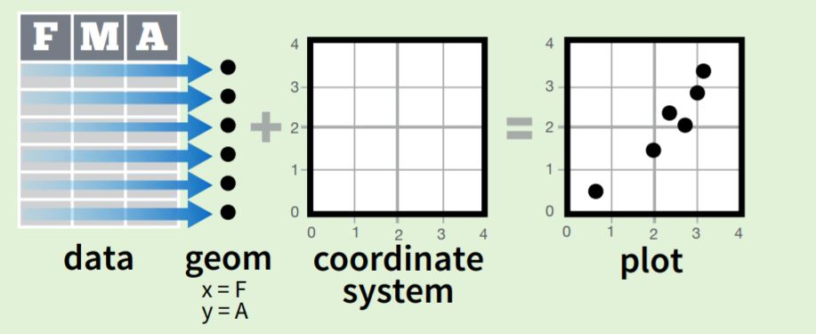

Before we start plotting we need to load the library and see the format of our data.

```r
library(ggplot2)
mpg
```

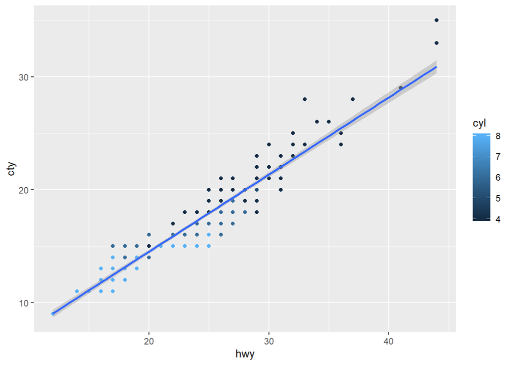

```r
ggplot(mpg, aes(hwy, cty)) +
 geom_point(aes(color = cyl)) +
 geom_smooth(method ="lm") + # Add the regression line to our data
 coord_cartesian() + # We can use coord_cartesian() to set the limits on the coordinate
  # system performs a visual zoom. For example, coord_cartesian(xlim = c(20, 40))
 scale_color_gradient()
```

## 4.2 Try different themes

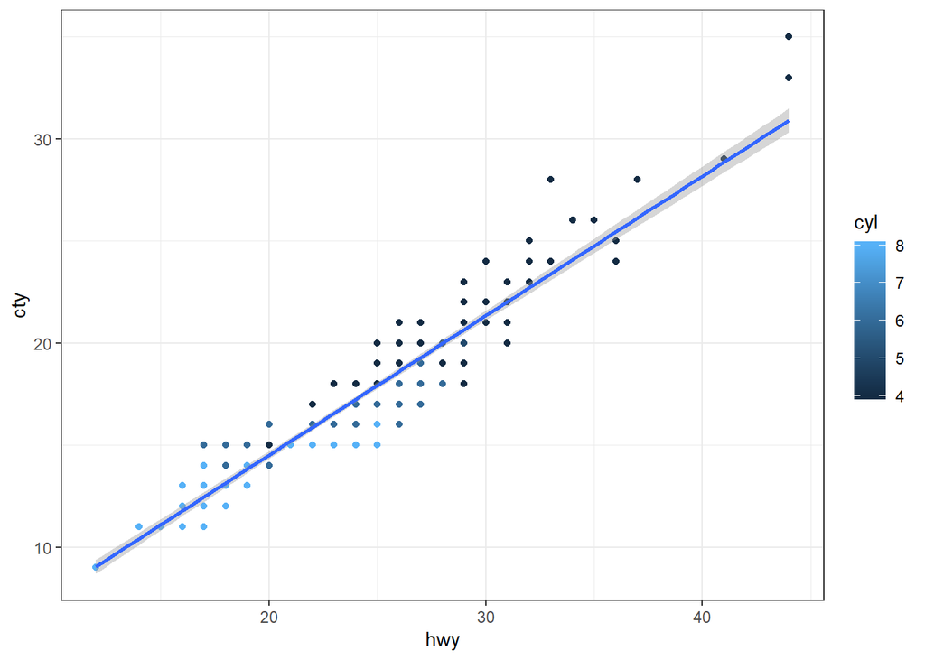

```r
ggplot(mpg, aes(hwy, cty)) +
 geom_point(aes(color = cyl)) +
 geom_smooth(method ="lm") +
 coord_cartesian() +
 scale_color_gradient() +
  theme_bw()
```

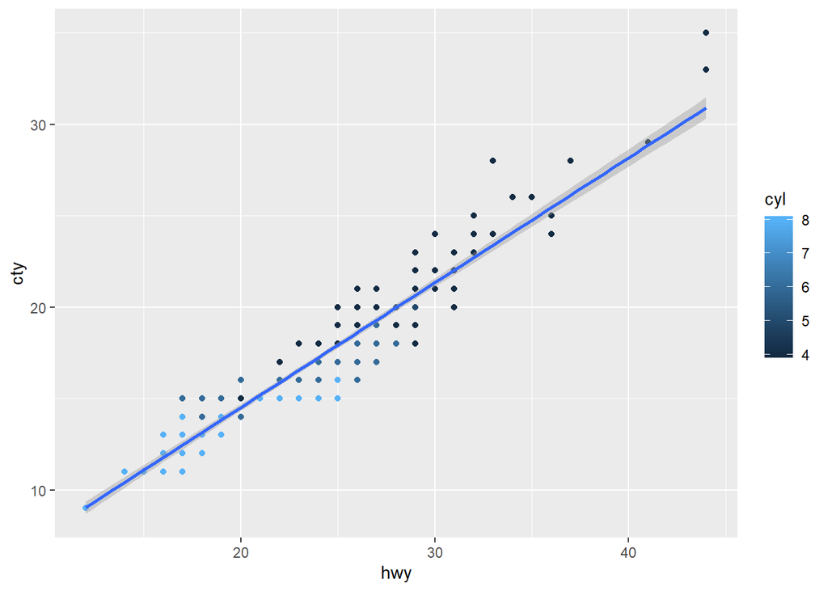

```r
ggplot(mpg, aes(hwy, cty)) +
 geom_point(aes(color = cyl)) +
 geom_smooth(method ="lm") +
 coord_cartesian() +
 scale_color_gradient() +
  theme_grey()
```

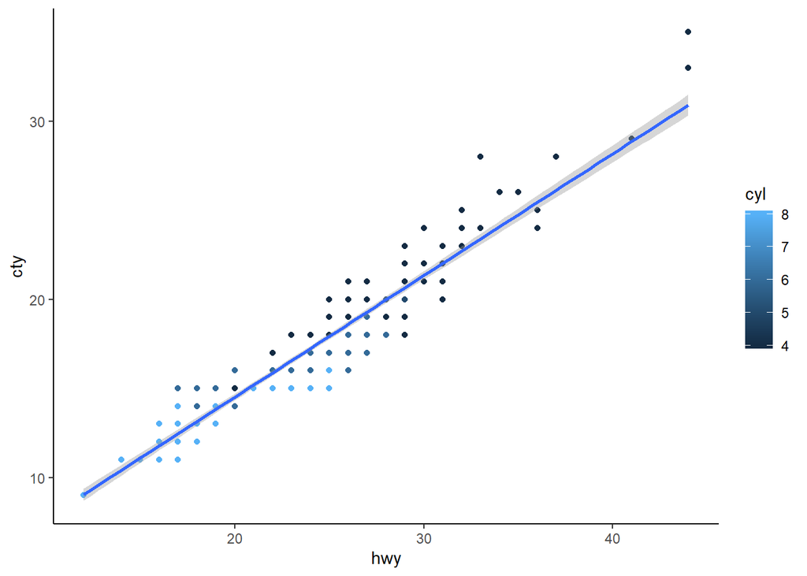

```r
ggplot(mpg, aes(hwy, cty)) +
 geom_point(aes(color = cyl)) +
 geom_smooth(method ="lm") +
 coord_cartesian() +
 scale_color_gradient() +
 theme_classic()
```

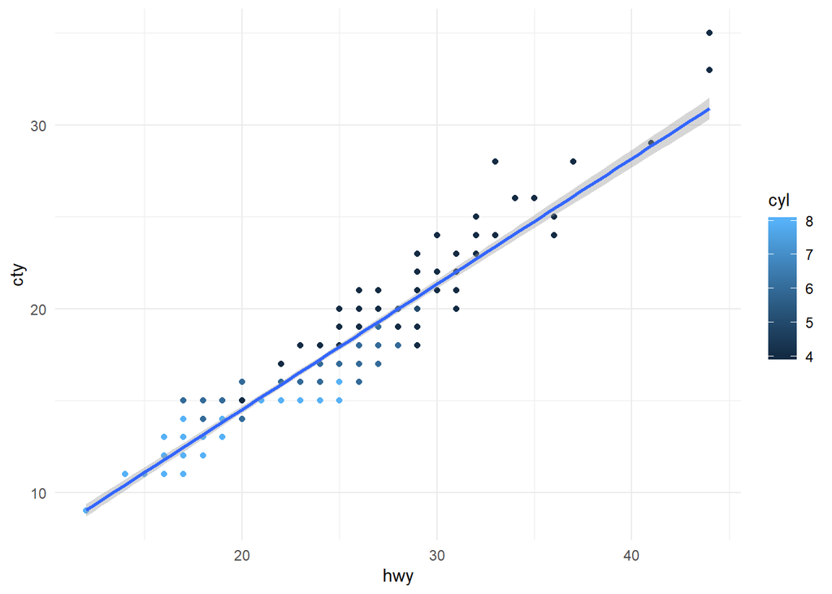

```r
ggplot(mpg, aes(hwy, cty)) +
 geom_point(aes(color = cyl)) +
 geom_smooth(method ="lm") +
 coord_cartesian() +
 scale_color_gradient() +
 theme_minimal()
```

## 4.3 Add Faceting and create a customized theme

We can also include facets that divide a plot into subplots based on the values of one or more discrete variables. Also we will change the theme (background coloring)to make our plots more appealing.

For more coloring options please refer to [“R color cheatsheet”](https://www.nceas.ucsb.edu/sites/default/files/2020-04/colorPaletteCheatsheet.pdf)

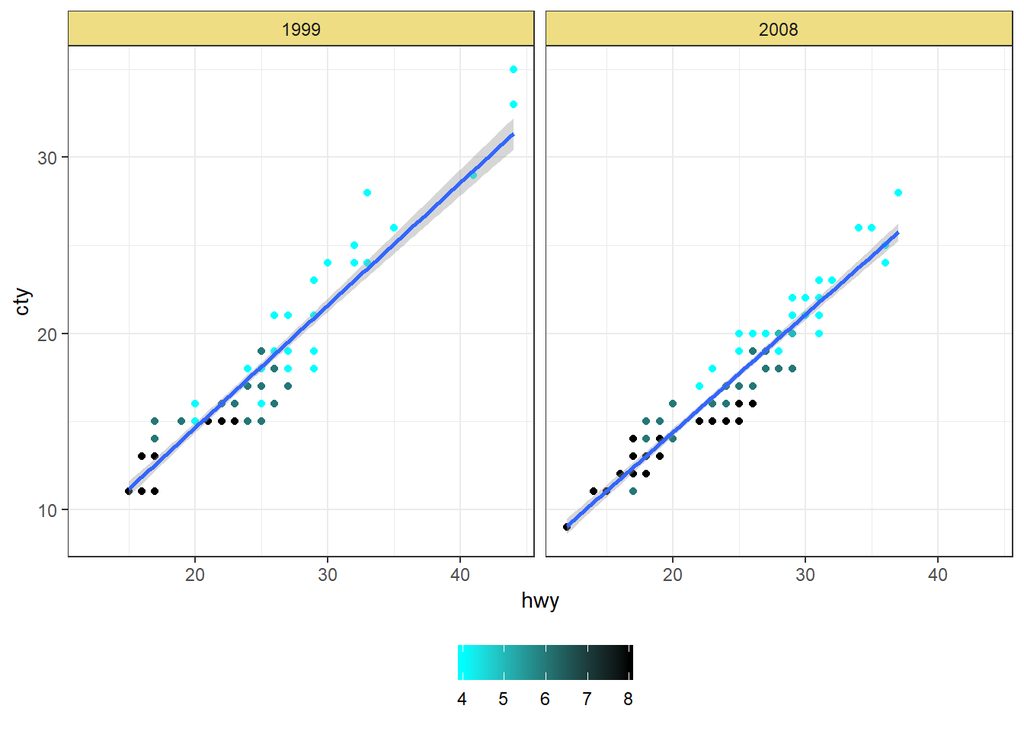

```r
# Introduce the customized theme
my_theme <- theme_bw() +
    theme(strip.background =
    element_rect(fill="lightgoldenrod"),
    legend.position="bottom",
    legend.title=element_blank(),
    plot.background = element_rect(fill="white",colour=NA) )

# Plot again using the new customized theme and faceting
ggplot(mpg, aes(x = hwy, y = cty)) +
    geom_point(aes(color = cyl)) +
    geom_smooth(method ="lm") +
    facet_wrap(.~year)+
    coord_cartesian() +
    scale_color_gradient(low = "cyan", high = "black") +
    my_theme
```

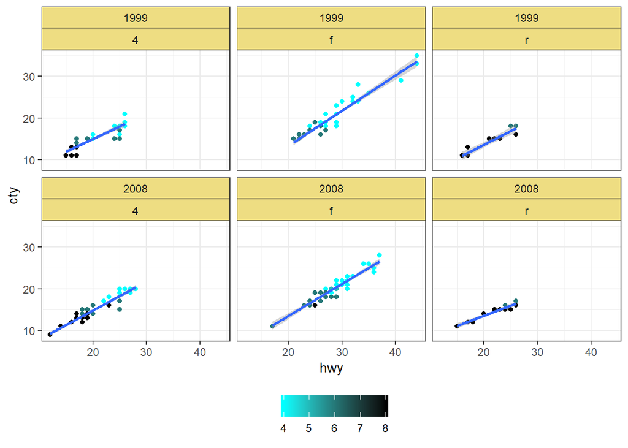

```r
# Fsacet into both rows and columns
ggplot(mpg, aes(x = hwy, y = cty)) +
    geom_point(aes(color = cyl)) +
    geom_smooth(method ="lm") +
    facet_wrap(year~drv)+
    coord_cartesian() +
    scale_color_gradient(low = "cyan", high = "black") +
    my_theme
```

## 4.4 Position Adjustments

Position adjustments determine how to arrange geoms that would otherwise occupy the same space.

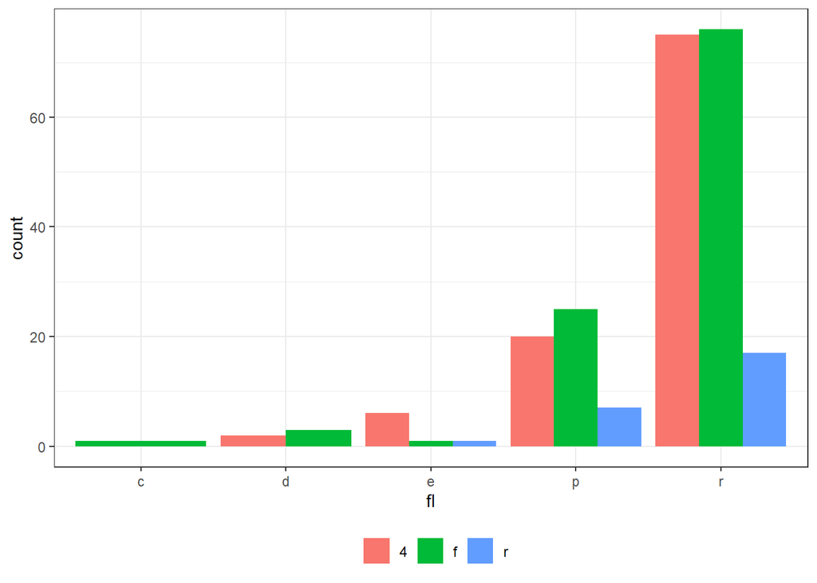

```r
s <- ggplot(mpg, aes(fl, fill = drv))

# Arrange elements side by side
s + geom_bar(position = "dodge")+
    my_theme
```

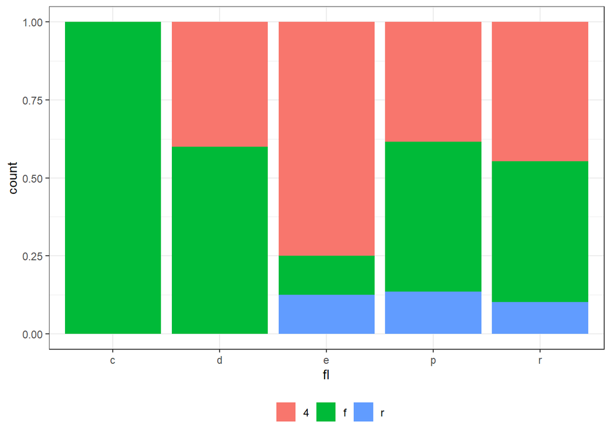

```r
# Stack elements on top of one another, normalize height
s + geom_bar(position = "fill")+
    my_theme
```

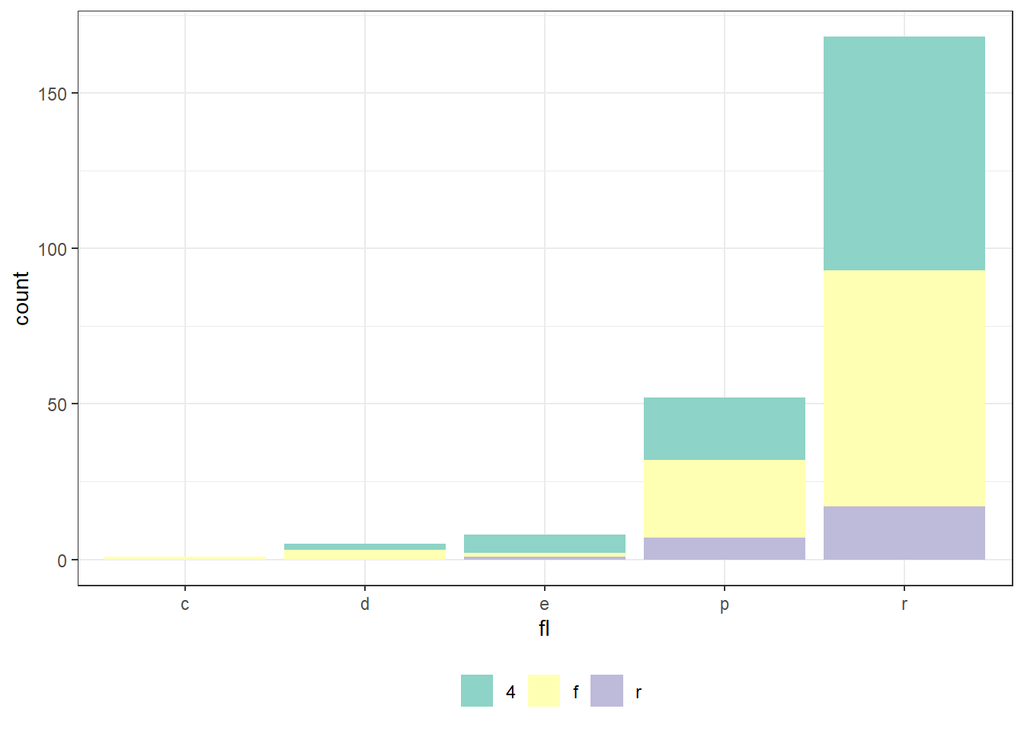

```r
# Stack elements on top of one another
s + geom_bar(position = "stack")+
    my_theme+
  scale_fill_brewer(palette="Set3")
```

## 4.5 Change the labels, titles and color

Let’s try to use geom_bar and change the labels and titles

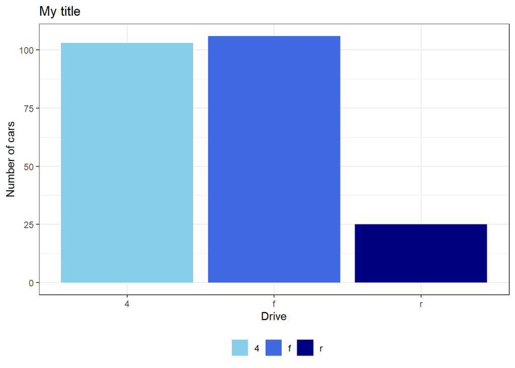

```r
ggplot(mpg, aes(drv)) +
  geom_bar(aes(fill = drv)) +
  my_theme +
  scale_fill_manual(
  values = c("skyblue", "royalblue","navy")) +
  ggtitle("My title") +
  xlab("Drive")+
  ylab("Number of cars")
```

## 4.6 Some additional plots with Discrete and Continuous variables

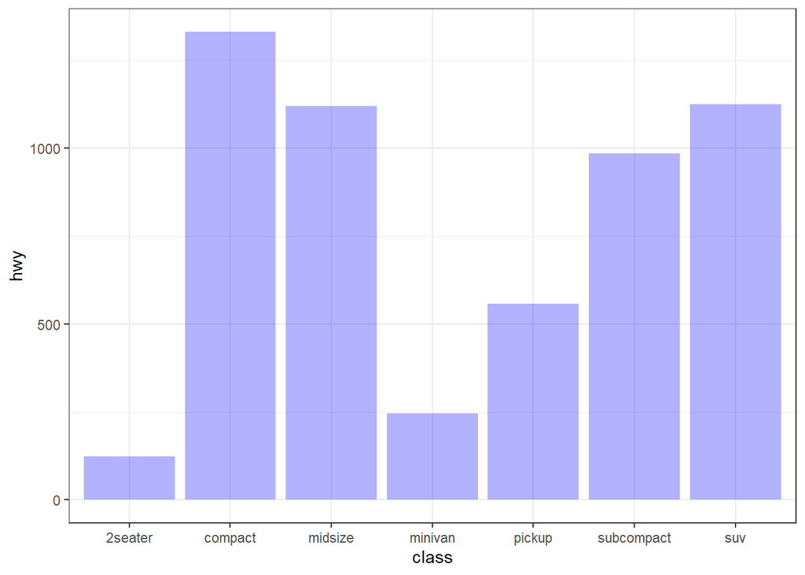

```r
g <- ggplot(mpg, aes(class, hwy))

g + geom_bar(stat = "identity",
             alpha = 0.3,   # Alpha refers to the opacity of a geom. Values of alpha range from 0 to 1,
                            # with lower values corresponding to more transparent colors.
             fill = "blue"  # Chagne the color of the bars
             ) +
              my_theme
```

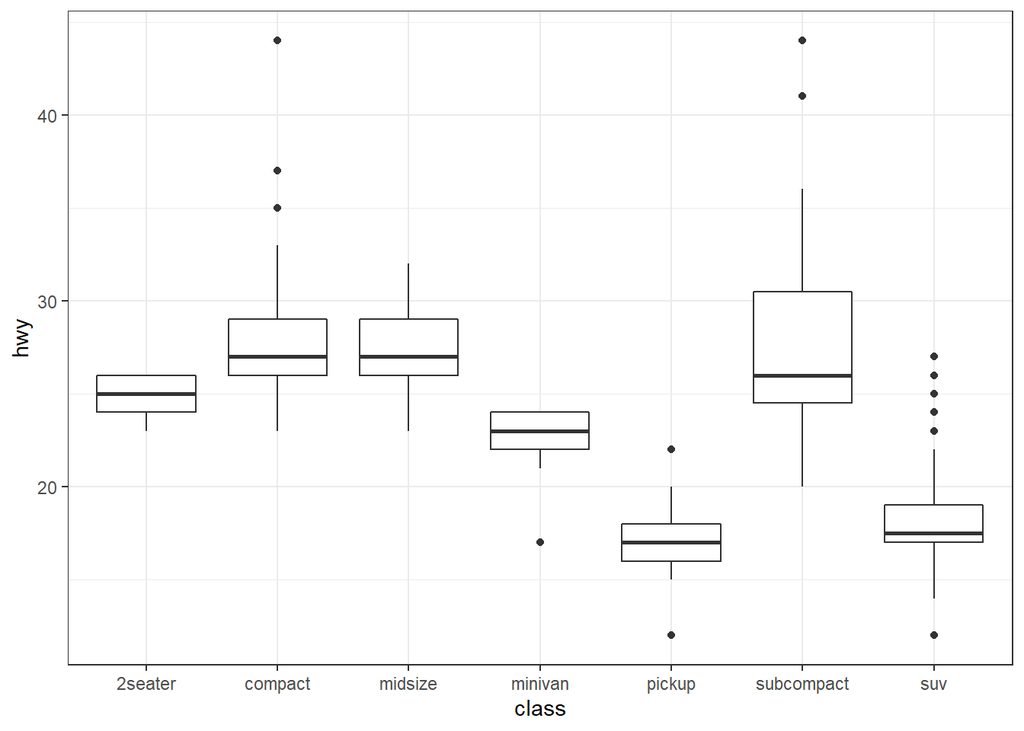

```r
g + geom_boxplot() +
              my_theme
```

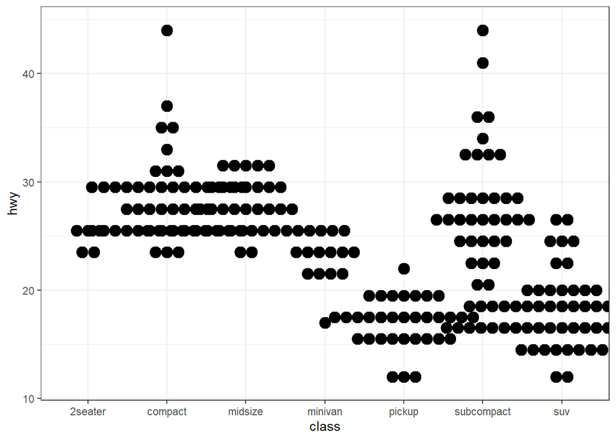

```r
g + geom_dotplot(binaxis = "y" , stackdir = "center") +
              my_theme
```

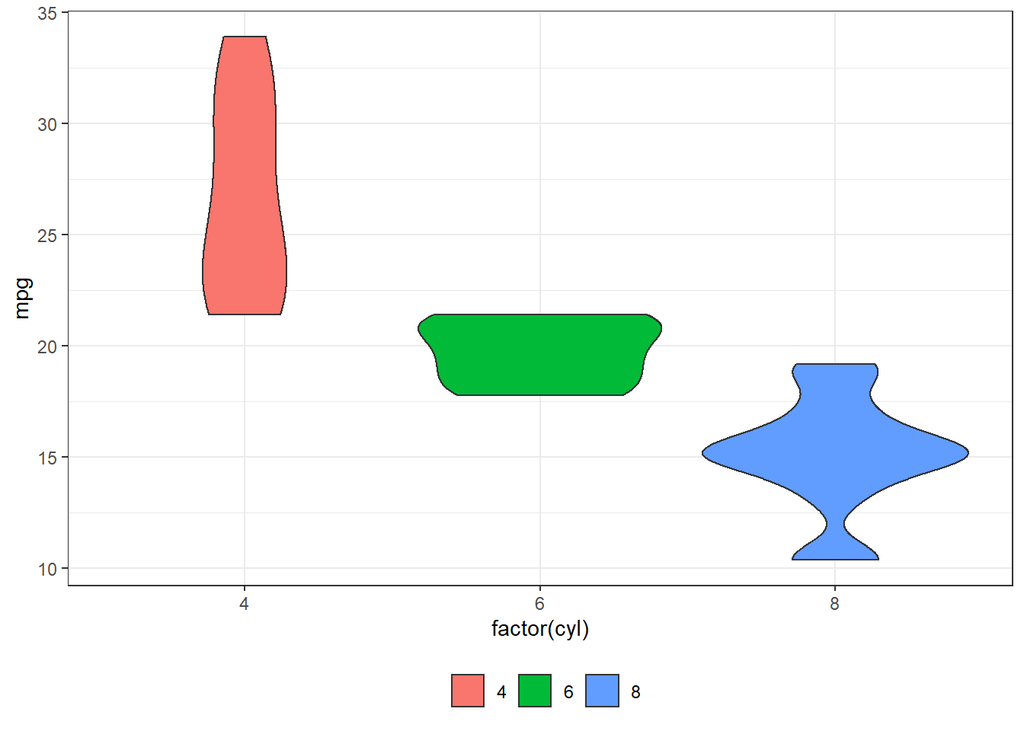

```r
ggplot(mtcars, aes(factor(cyl), mpg)) +
  geom_violin(aes(fill = factor(cyl)))+
              my_theme
```

## 4.7 Some plots with maps

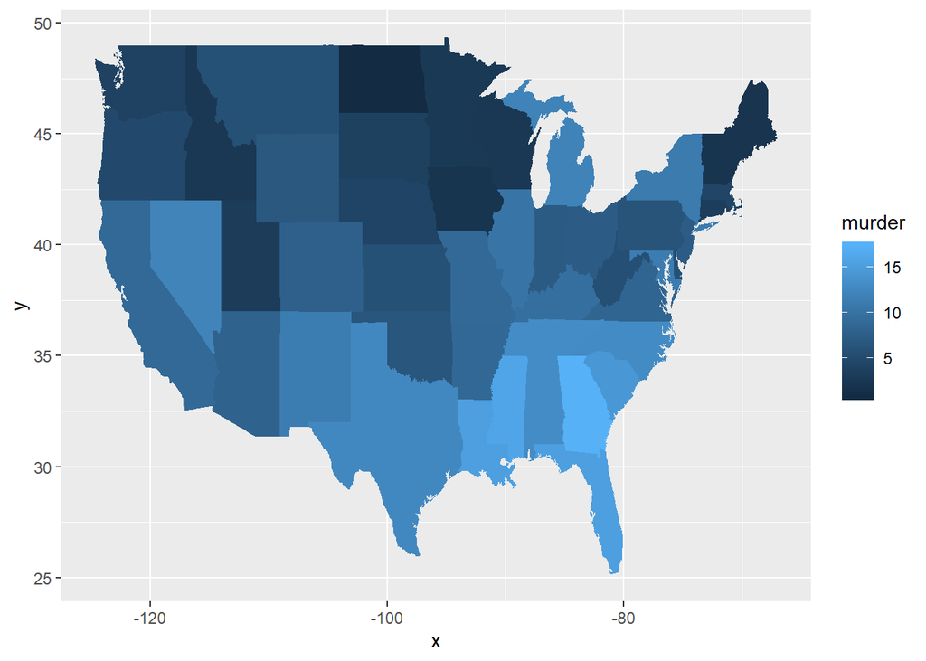

```r
library(maps)
data <- data.frame(murder = USArrests$Murder, state = tolower(rownames(USArrests)))

map <- map_data("state")
ggplot(data, aes(fill = murder)) +
  geom_map(aes(map_id = state), map = map) +
expand_limits(x = map$long, y = map$lat)
```

## 4.8 Alluvial Plots in ggplot2

For more information please refer to this [link](https://cran.r-project.org/web/packages/ggalluvial/vignettes/ggalluvial.html)

```r
# load required library
library(ggalluvial)
```

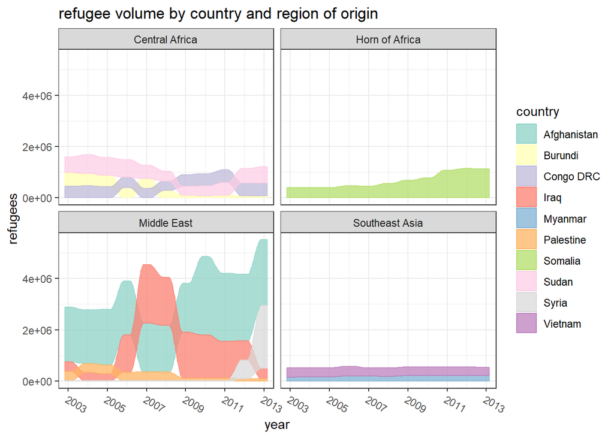

```r
############################
############################
# Plot No 1
############################
############################

# some data manipulation before ploting
data(Refugees, package = "alluvial")
country_regions <- c(
  Afghanistan = "Middle East",
  Burundi = "Central Africa",
  `Congo DRC` = "Central Africa",
  Iraq = "Middle East",
  Myanmar = "Southeast Asia",
  Palestine = "Middle East",
  Somalia = "Horn of Africa",
  Sudan = "Central Africa",
  Syria = "Middle East",
  Vietnam = "Southeast Asia"
)

Refugees$region <- country_regions[Refugees$country]

ggplot(data = Refugees,
       aes(x = year, y = refugees, alluvium = country)) +
  geom_alluvium(aes(fill = country, colour = country),
                alpha = .75, decreasing = FALSE) +
  scale_x_continuous(breaks = seq(2003, 2013, 2)) +
  theme_bw() +
  theme(axis.text.x = element_text(angle = -30, hjust = 0)) +
  scale_fill_brewer(type = "qual", palette = "Set3") +
  scale_color_brewer(type = "qual", palette = "Set3") +
  facet_wrap(~ region, scales = "fixed") +
  ggtitle("refugee volume by country and region of origin")
```

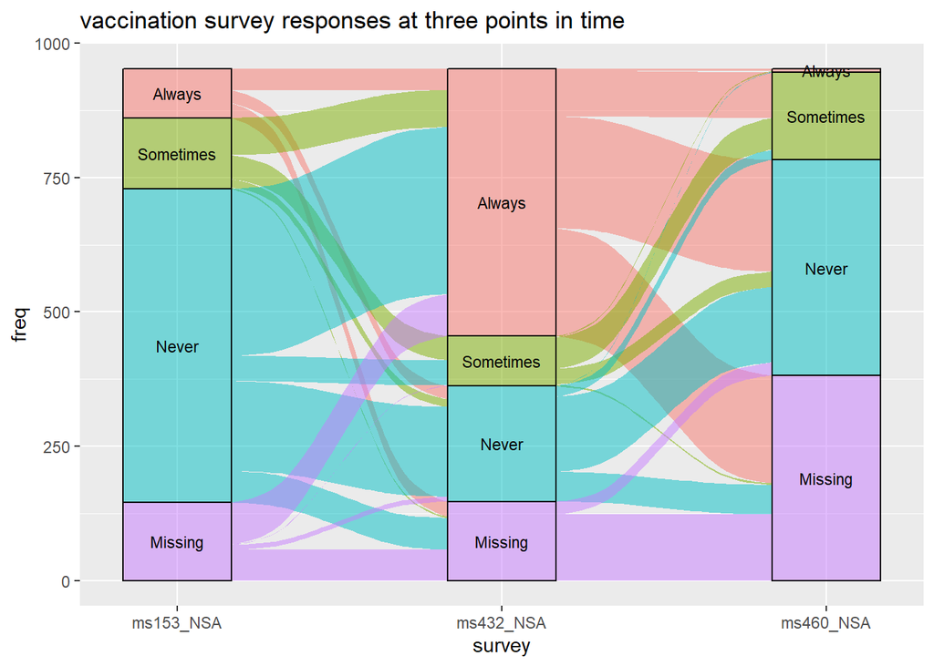

```r
############################
############################
# Plot No 2
############################
############################

data(vaccinations)

levels(vaccinations$response) <- rev( levels ( vaccinations$response ) )

ggplot(vaccinations,
       aes(x = survey, stratum = response, alluvium = subject,
           y = freq,
           fill = response, label = response)) +
  scale_x_discrete(expand = c(.1, .1)) +
  geom_flow() +
  geom_stratum(alpha = .5) +
  geom_text(stat = "stratum", size = 3) +
  theme(legend.position = "none") +
  ggtitle("vaccination survey responses at three points in time")
```

## 4.9 Save plots to pdf and generate multiple plots

This sections shows how to draw multiple plot and save them as pdf files

```r
library(tidyverse)

data_plot <- readxl::read_excel("C:/WBG/LocalITUtilities/R_tutorial/data/data_plot.xlsx")
```

```
## * `` -> ...1
```

```r
list_countries <-unique(data_plot$Country)
plot_list = list()

for (i in seq( 1 , 3 ) ){
# for (i in seq(1, length(list_countries) ) ){


  title<- paste(list_countries[i] )

 p<- ggplot() +
    geom_line( data = filter(data_plot, Year>=2010 & Country == list_countries[i]& WEO == "2019") ,
               aes(x= Year, y=debttogdp, color = WEO), size=1.1, alpha = 1 )+
    geom_line(data = filter(data_plot, Year>=2010 & Country == list_countries[i]& WEO != "2019"),
              aes(x= Year, y=debttogdp, color = WEO), size=1.05, alpha = 0.55 )+
    my_theme+
    scale_y_continuous("Debt-to-GDP")  +
    ggtitle(title)+
    scale_color_brewer(palette="Set3") +
    scale_x_continuous(breaks=seq(2010,2019,2)) # reorginize the ticks of x-axis

  plot_list[[i]] = p

}


# setwd("")
pdf("C:/WBG/LocalITUtilities/R_tutorial/data/WEO_vintages_graph2.pdf")


for (i in seq(1, 3 ) ){
  print(plot_list[[i]])
}
dev.off()
```

# 5 Model Data

## 5.1 Starting with the basics

Let’s load some debt data:

```r
dat <- read.csv("C:/WBG/LocalITUtilities/R_tutorial/data/SimpReg.csv",na.strings=c(""," ","NA")) #
```

Open the data and notice that the data is in **semi long format** - meaning there is one time and country column with multiple explanatory variables.

```
USE THE CODE BELOW IF YOU WANT TO PULL DATA USING AN API
library(WDI)

cty <- c("BRA","CHL","PER","RUS","ZAF")

varswdi <- c("NY.GDP.MKTP.CD","GC.DOD.TOTL.CN","DT.DOD.DPNG.CD","GC.XPN.TOTL.GD.ZS",
             "GC.REV.XGRT.GD.ZS","BN.CAB.XOKA.GD.ZS") #

# WDI DATA
dat = WDI(indicator=varswdi, country=cty, extra =TRUE,start=1990, end=2017)

# CREATE ADDITIONAL WDI SERIES (SHARES OF GDP)
dat$DT.DOD.DPNG.CD_<-dat$DT.DOD.DPNG.CD/dat$NY.GDP.MKTP.CD  # External debt (Private non-guaranteed)
dat$GC.DOD.TOTL.CN_<-dat$GC.DOD.TOTL.CN/dat$NY.GDP.MKTP.CD  # Total debt (central gov) debt
dat$GB.BAL.OVRL.GDP.ZS_<-(dat$GC.REV.XGRT.GD.ZS-dat$GC.XPN.TOTL.GD.ZS)/100 # Government budget balance (%GDP)
dat$BN.CAB.XOKA.GD.ZS_<-dat$BN.CAB.XOKA.GD.ZS/100  #Current account balance (%GDP)
colnames(dat)[3]<-"Year"
colnames(dat)[21]<-"Country"
```

Let’s assume our objective it to estimate the impact of debt on GDP growth:

$$\Delta ln(Y_t) = \alpha+\beta \frac{D_t}{Y_t P_t}+\varepsilon_t$$
Let’s use our knowledge from Tibbles and create a dataframe with only these variables (in-class exercise):

```r
dat<-dat %>% group_by(Country) %>% mutate(ly = log(NY.GDP.MKTP.KN),
                                          lylag = lag(ly, order_by=Country),
                                          dly = 100*(ly-lylag))  # Lag differences

 # Tables

#d <- dat %>% select(Country,Year,dly,ly,GC.DOD.TOTL.CN_,GB.BAL.OVRL.GDP.ZS,BN.CAB.XOKA.GD.ZS_) %>% as_tibble(dat)
d <- dat %>% select(Country,Year,dly,ly,GG.DBT.TOTL.CN_,GG.BAL.OVRL.CN_,BN.CAB.OVRL.CD_) %>% as_tibble(dat)
rm(dat)
```

## 5.2 Some basic regression analysis - OLS

Let’s start by simply plotting the relationship:

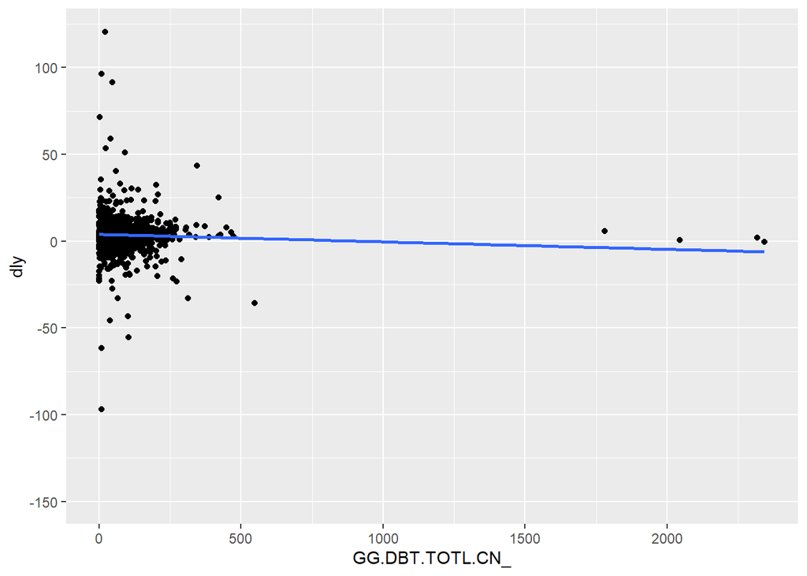

```r
d %>% ggplot(aes(x=GG.DBT.TOTL.CN_,y=dly))+geom_point()+geom_smooth(method = lm, se = FALSE)
```

Let’s remove the outliers

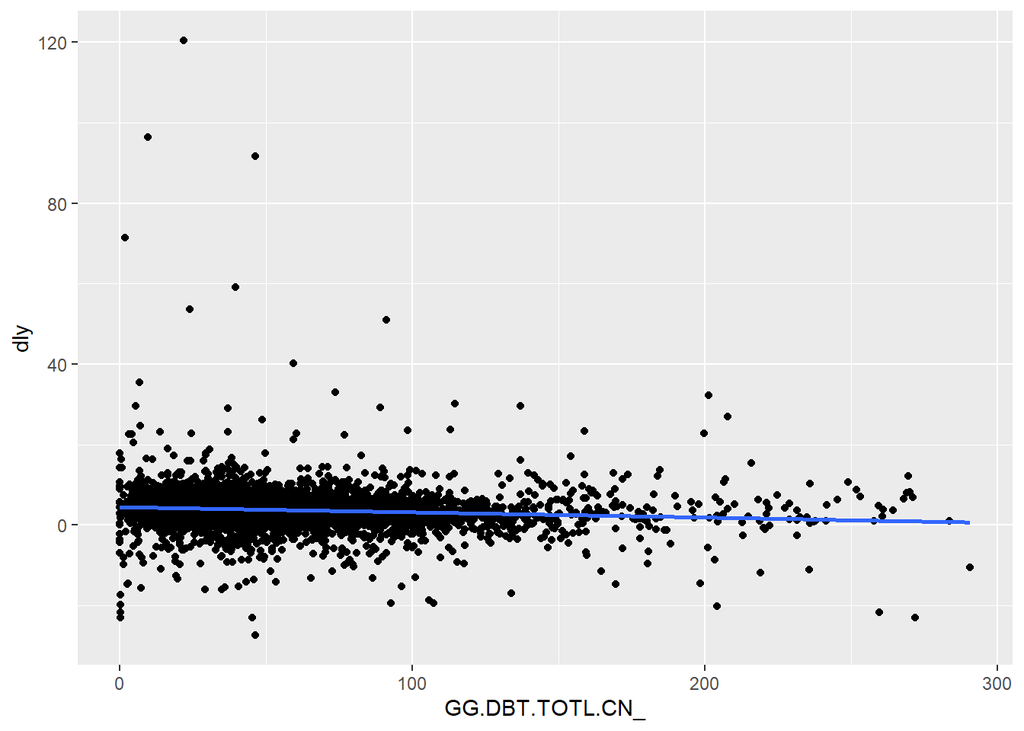

```r
dd <- d %>% filter(GG.DBT.TOTL.CN_<300,dly> -30)
dd %>% ggplot(aes(x=GG.DBT.TOTL.CN_,y=dly))+geom_point()+geom_smooth(method = lm, se = FALSE)
```

Remember that this is across all countries and all periods. If you wanted to do the same plot for different countries over different periods then use the **filter command**.

Now let’s run our first regression (pooled) using the built-in **lm** command. In **R** we make use of formulas where the equal sign should be **~**.

The block below creates a simple regression called **reg1**. We use **summary** to pull out the statistics while **fitted** generates the fitted values of the series. We can plot the prediction using GGPLOT:

```r
reg1 <- lm(dly~GG.DBT.TOTL.CN_,data=dd)
summary(reg1)
```

```
##
## Call:
## lm(formula = dly ~ GG.DBT.TOTL.CN_, data = dd)
##
## Residuals:
##     Min      1Q  Median      3Q     Max
## -31.354  -1.950  -0.100   1.924 116.208
##
## Coefficients:
##                  Estimate Std. Error t value Pr(>|t|)
## (Intercept)      4.513005   0.136833  32.982  < 2e-16 ***
## GG.DBT.TOTL.CN_ -0.013015   0.001936  -6.722 2.01e-11 ***
## ---
## Signif. codes:  0 '***' 0.001 '**' 0.01 '*' 0.05 '.' 0.1 ' ' 1
##
## Residual standard error: 5.313 on 4504 degrees of freedom
## Multiple R-squared:  0.009933,   Adjusted R-squared:  0.009713
## F-statistic: 45.19 on 1 and 4504 DF,  p-value: 2.015e-11
```

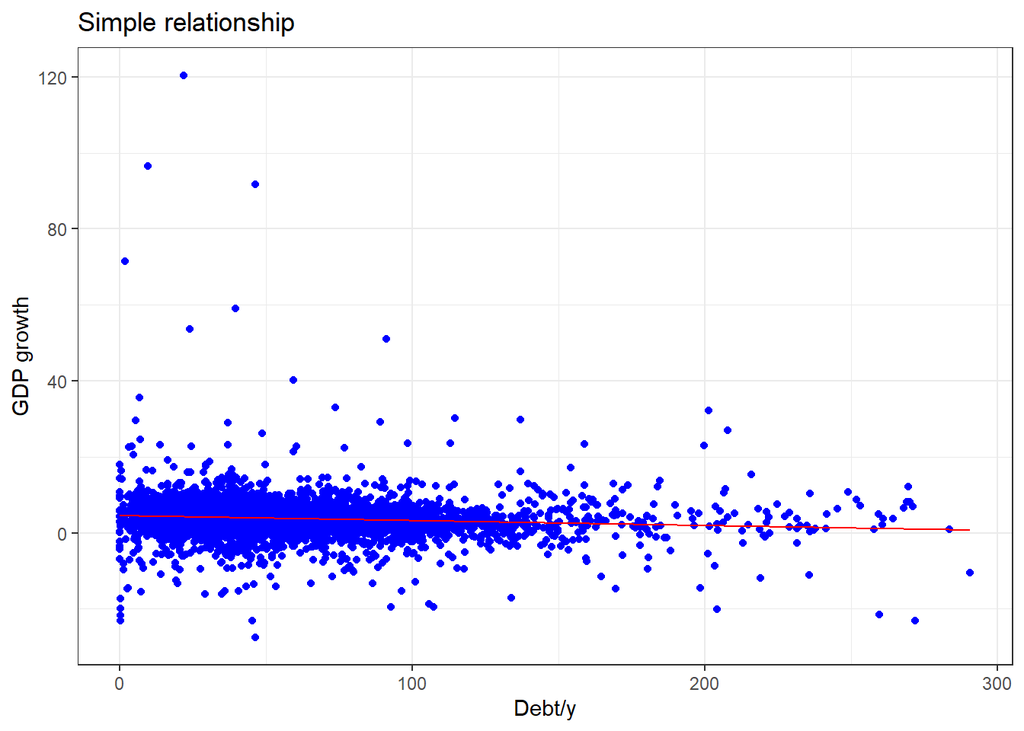

```r
#plot(dly~GC.DOD.TOTL.CN_,data=d,main="OLS regression")
#abline(a=reg1$coefficients[1],b=reg1$coefficients[2],col="red")

# PREDICTED = YHAT
# predicted_df <- data.frame(dlyHAT = predict(reg1, d), dy=d$GC.DOD.TOTL.CN_) # For simple predicted lines
# FITTED VALUES FOR ADDUBG THE REGRESSION LINE
# fit_df<-simp$fitted
test <- fortify(reg1)
ggplot(data = test, aes(x = GG.DBT.TOTL.CN_, y = dly))+geom_point(color='blue')+
  geom_line(color='red',aes(y=.fitted, x=GG.DBT.TOTL.CN_))+
  labs(title="Simple relationship",x="Debt/y",y="GDP growth")+theme_bw()
```

## 5.3 Panel regression methods

Note that running pooled OLS will give us biased coefficients (apart from other problems such as endogeneity and causality, for which you need a structural model). We can get around the pooled assumption by either demeaning the data or using least square dummy variables.

For LSDV use:

```r
fixed.dum <-lm(dly ~ GG.DBT.TOTL.CN_ + factor(Country) - 1, data=dd)
summary(fixed.dum)
```

```
##
## Call:
## lm(formula = dly ~ GG.DBT.TOTL.CN_ + factor(Country) - 1, data = dd)
##
## Residuals:
##     Min      1Q  Median      3Q     Max
## -31.538  -1.577   0.093   1.681 112.421
##
## Coefficients:
##                     Estimate Std. Error t value Pr(>|t|)
## GG.DBT.TOTL.CN_    -0.021254   0.002692  -7.895 3.65e-15 ***
## factor(Country)AFG  7.294001   1.236982   5.897 3.99e-09 ***
## factor(Country)AGO  7.518567   1.145099   6.566 5.78e-11 ***
## factor(Country)ALB  5.383874   1.048161   5.136 2.92e-07 ***
## factor(Country)ARE  4.844301   1.106754   4.377 1.23e-05 ***
## factor(Country)ARG  3.697742   0.971627   3.806 0.000143 ***
## factor(Country)ARM  7.239496   1.042538   6.944 4.38e-12 ***
## factor(Country)ATG  4.718044   0.961259   4.908 9.53e-07 ***
## factor(Country)AUS  3.507255   0.912753   3.843 0.000124 ***
## factor(Country)AUT  3.536096   0.915203   3.864 0.000113 ***
## factor(Country)AZE  7.088606   1.014448   6.988 3.22e-12 ***
## factor(Country)BDI  4.277268   1.157274   3.696 0.000222 ***
## factor(Country)BEL  4.183991   0.865269   4.835 1.37e-06 ***
## factor(Country)BEN  7.562439   1.108511   6.822 1.02e-11 ***
## factor(Country)BFA  6.300245   1.197695   5.260 1.51e-07 ***
## factor(Country)BGD  6.980953   1.233314   5.660 1.61e-08 ***
## factor(Country)BGR  2.976582   1.061338   2.805 0.005061 **
## factor(Country)BHR  5.354656   0.929807   5.759 9.05e-09 ***
## factor(Country)BHS  1.724587   0.929147   1.856 0.063508 .
## factor(Country)BIH  4.793358   1.085289   4.417 1.03e-05 ***
## factor(Country)BLR  4.811884   1.231613   3.907 9.49e-05 ***
## factor(Country)BLZ  4.719216   1.188597   3.970 7.29e-05 ***
## factor(Country)BOL  5.262032   1.143041   4.604 4.27e-06 ***
## factor(Country)BRA  3.685153   1.146471   3.214 0.001317 **
## factor(Country)BRB  3.051780   1.023027   2.983 0.002869 **
## factor(Country)BTN  8.532852   0.995639   8.570  < 2e-16 ***
## factor(Country)BWA  4.377046   1.081257   4.048 5.25e-05 ***
## factor(Country)CAF  4.379380   1.095832   3.996 6.54e-05 ***
## factor(Country)CAN  4.009492   0.839306   4.777 1.84e-06 ***
## factor(Country)CHE  2.759010   0.841867   3.277 0.001057 **
```

[output cut: 138 more lines]

```
## factor(Country)VCT  3.773150   0.940230   4.013 6.10e-05 ***
## factor(Country)VEN -0.245409   1.113376  -0.220 0.825556
## factor(Country)VNM  7.342142   1.140063   6.440 1.32e-10 ***
## factor(Country)VUT  3.478968   0.944261   3.684 0.000232 ***
## factor(Country)XKX  5.414820   1.267395   4.272 1.98e-05 ***
## factor(Country)YEM  3.460232   1.071126   3.230 0.001245 **
## factor(Country)ZAF  3.108327   0.889184   3.496 0.000478 ***
## factor(Country)ZMB  7.365058   1.153387   6.386 1.89e-10 ***
## factor(Country)ZWE  3.263840   1.316928   2.478 0.013236 *
## ---
## Signif. codes:  0 '***' 0.001 '**' 0.01 '*' 0.05 '.' 0.1 ' ' 1
##
## Residual standard error: 5.069 on 4329 degrees of freedom
## Multiple R-squared:  0.4213, Adjusted R-squared:  0.3976
## F-statistic:  17.8 on 177 and 4329 DF,  p-value: < 2.2e-16
```

Or better yet (what I use many times) is the PLM package for both country and year fixed effects:

```r
library(plm)
fixedfin <-plm(dly ~ GG.DBT.TOTL.CN_,data=dd, index=c("Country","Year"),model="within")
summary(fixedfin)
```

```
## Oneway (individual) effect Within Model
##
## Call:
## plm(formula = dly ~ GG.DBT.TOTL.CN_, data = dd, model = "within",
##     index = c("Country", "Year"))
##
## Unbalanced Panel: n = 176, T = 7-39, N = 4506
##
## Residuals:
##       Min.    1st Qu.     Median    3rd Qu.       Max.
## -31.538489  -1.577249   0.092886   1.681298 112.420667
##
## Coefficients:
##                  Estimate Std. Error t-value  Pr(>|t|)
## GG.DBT.TOTL.CN_ -0.021254   0.002692 -7.8952 3.645e-15 ***
## ---
## Signif. codes:  0 '***' 0.001 '**' 0.01 '*' 0.05 '.' 0.1 ' ' 1
##
## Total Sum of Squares:    112830
## Residual Sum of Squares: 111230
## R-Squared:      0.014195
## Adj. R-Squared: -0.025884
## F-statistic: 62.3345 on 1 and 4329 DF, p-value: 3.6451e-15
```

Notice that the coefficient is the same for the DLSV method and that of the quasi-demeaned approach from PLM.

Next, we can extract the fixed effects (options in **level**, **demean**).

```r
fixef(fixedfin,type="level")
```

```
##      AFG      AGO      ALB      ARE      ARG      ARM      ATG      AUS
##  7.29400  7.51857  5.38387  4.84430  3.69774  7.23950  4.71804  3.50725
##      AUT      AZE      BDI      BEL      BEN      BFA      BGD      BGR
##  3.53610  7.08861  4.27727  4.18399  7.56244  6.30025  6.98095  2.97658
##      BHR      BHS      BIH      BLR      BLZ      BOL      BRA      BRB
##  5.35466  1.72459  4.79336  4.81188  4.71922  5.26203  3.68515  3.05178
##      BTN      BWA      CAF      CAN      CHE      CHL      CHN      CIV
##  8.53285  4.37705  4.37938  4.00949  2.75901  4.78170  9.25913  4.95019
##      CMR      COD      COG      COL      COM      CPV      CRI      CYP
##  4.98279  5.74371  5.51010  4.13687  3.83347  7.52083  4.71621  4.31653
##      CZE      DEU      DJI      DMA      DNK      DOM      DZA      ECU
##  3.27312  2.81061  3.89495  3.20073  2.70634  5.64346  7.42886  4.24629
##      EGY      ERI      ESP      EST      ETH      FIN      FRA      GAB
##  6.38795  7.40298  3.48398  4.11113  8.77930  2.80259  2.94183  3.53037
##      GBR      GEO      GHA      GIN      GMB      GNB      GNQ      GRC
##  3.29803  6.10046  6.47141  5.95582  4.66223  6.32070 12.48007  3.09796
##      GRD      GTM      GUY      HND      HRV      HTI      HUN      IDN
##  4.32770  4.00021  5.59684  4.88745  3.59947  2.04736  3.94534  4.97760
##      IND      IRL      IRN      IRQ      ISL      ISR      ITA      JAM
##  7.59667  6.34987  2.83351  6.85886  3.80149  5.10565  3.32647  3.53475
##      JOR      JPN      KAZ      KEN      KGZ      KHM      KNA      KOR
##  6.05725  4.87011  6.57565  5.50664  5.81930  7.98808  4.94613  5.40002
##      KWT      LAO      LBN      LBR      LBY      LCA      LKA      LSO
##  3.67891  8.26551  8.70378  4.73677  5.07873  3.15638  6.62843  4.96453
##      LTU      LUX      LVA      MAR      MDA      MDG      MDV      MEX
##  4.45398  3.61150  4.13745  4.98757  8.48016  3.94449  6.42539  3.38144
##      MKD      MLI      MLT      MMR      MNE      MNG      MOZ      MRT
##  3.67505  5.49268  5.39343 10.94503  4.21649  8.31884  7.94854  6.49008
##      MUS      MWI      MYS      NAM      NER      NGA      NIC      NLD
##  5.48453  6.02792  6.69484  3.91529  5.68089  5.04040  4.47340  3.39956
##      NOR      NPL      NZL      OMN      PAK      PAN      PER      PHL
##  3.14548  5.24605  3.36378  4.00563  5.60387  6.50816  5.29738  5.62615
##      POL      PRT      PRY      PSE      QAT      ROU      RUS      RWA
##  5.09991  3.20458  3.68887  3.43826  8.38353  3.64312  3.36575  9.91364
##      SAU      SDN      SEN      SGP      SLB      SLE      SLV      SRB
##  3.94197  7.17743  5.23715  7.51644  5.17324  7.25705  3.58839  5.11074
##      SSD      STP      SUR      SVK      SVN      SWE      SWZ      SYC
## -0.54353  7.23144  3.10784  4.74442  3.63067  3.44738  3.34918  6.37989
##      SYR      TCD      TGO      THA      TJK      TLS      TTO      TUN
##  2.01576  6.59098  6.31841  4.09808  8.27691  2.94694  2.90713  4.96902
##      TUR      TZA      UGA      UKR      URY      USA      UZB      VCT
##  5.61137  7.02697  6.77349  2.72628  4.26950  3.77688  6.71696  3.77315
##      VEN      VNM      VUT      XKX      YEM      ZAF      ZMB      ZWE
## -0.24541  7.34214  3.47897  5.41482  3.46023  3.10833  7.36506  3.26384
```

We can do the standard test of whether fixed effects is better than OLS (H0: OLS is better than FE)

```r
pFtest(fixedfin,reg1)
```

```
##
##  F test for individual effects
##
## data:  dly ~ GG.DBT.TOTL.CN_
## F = 3.5357, df1 = 175, df2 = 4329, p-value < 2.2e-16
## alternative hypothesis: significant effects
```

The results reject the null hypothesis - use fixed effects.

How about if we do a random effects model (when would we typically do this - think of between and within group variability)?

```r
library(plm)
Randfin <-plm(dly ~ GG.DBT.TOTL.CN_,data=dd, index=c("Country","Year"),model="random")
summary(Randfin)
```

```
## Oneway (individual) effect Random Effect Model
##    (Swamy-Arora's transformation)
##
## Call:
## plm(formula = dly ~ GG.DBT.TOTL.CN_, data = dd, model = "random",
##     index = c("Country", "Year"))
##
## Unbalanced Panel: n = 176, T = 7-39, N = 4506
##
## Effects:
##                  var std.dev share
## idiosyncratic 25.694   5.069 0.912
## individual     2.465   1.570 0.088
## theta:
##    Min. 1st Qu.  Median    Mean 3rd Qu.    Max.
##  0.2265  0.4330  0.4650  0.4677  0.4922  0.5407
##
## Residuals:
##    Min. 1st Qu.  Median    Mean 3rd Qu.    Max.
## -31.496  -1.679   0.029  -0.016   1.637 114.388
##
## Coefficients:
##                   Estimate Std. Error z-value  Pr(>|z|)
## (Intercept)      4.8377290  0.1943699 24.8893 < 2.2e-16 ***
## GG.DBT.TOTL.CN_ -0.0175839  0.0023386 -7.5191 5.514e-14 ***
## ---
## Signif. codes:  0 '***' 0.001 '**' 0.01 '*' 0.05 '.' 0.1 ' ' 1
##
## Total Sum of Squares:    117730
## Residual Sum of Squares: 115790
## R-Squared:      0.016584
## Adj. R-Squared: 0.016366
## Chisq: 75.3964 on 1 DF, p-value: < 2.22e-16
```

Which model do we prefer - fixed or random effects? Luckily there is a test to help us - the Hausman test, although it comes with strong caveats. Use fixed effects if p-value < 0.05.

```r
phtest(fixedfin,Randfin)
```

```
##
##  Hausman Test
##
## data:  dly ~ GG.DBT.TOTL.CN_
## chisq = 7.5749, df = 1, p-value = 0.005919
## alternative hypothesis: one model is inconsistent
```

Let’s plot the estimates for the three methods by adding the fitted values of the random and fixed effects model to the pooled estimate:

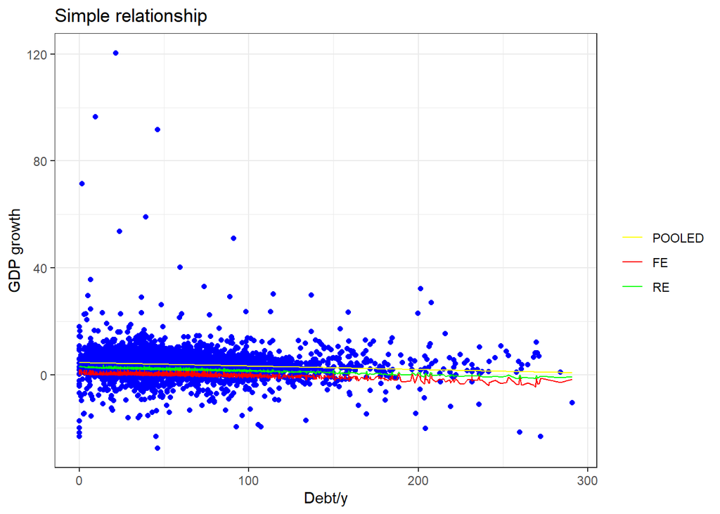

```r
fitPLMFE <- pmodel.response(fixedfin)-fixedfin$residuals
fitPLMRE <- pmodel.response(Randfin)-Randfin$residuals
test$PanelFE <- fitPLMFE
test$PanelRE <- fitPLMRE

ggplot(data = test, aes(x = GG.DBT.TOTL.CN_, y = dly))+geom_point(color='blue')+
  geom_line(aes(y=.fitted, x=GG.DBT.TOTL.CN_,color='POOLED'))+
  geom_line(aes(y=PanelFE, x=GG.DBT.TOTL.CN_,color='FE'))+
  geom_line(aes(y=PanelRE, x=GG.DBT.TOTL.CN_,color='RE'))+
  labs(title="Simple relationship",x="Debt/y",y="GDP growth")+
  scale_color_manual(name="",breaks=c("POOLED","FE","RE"),values=c("RED","YELLOW","GREEN"))+
  theme_bw()
```

For other types of tests like unit roots, heteroscedasticity and serial correlation read: [PLM Vignette](https://cran.r-project.org/web/packages/plm/plm.pdf)

# 6 Additional Resources

- https://github.com/ClaudiaBrauer/A-very-short-introduction-to-R (absolute basics)
- https://r4ds.had.co.nz/ (R for Data Science book)
- https://rmarkdown.rstudio.com/ (RMarkdown for writing reports, creating presentations,…)
- https://sites.google.com/site/econometricsacademy/ (Econometrics with R)
- https://www.econometrics-with-r.org/ (Econometrics with R)
- https://rstudio.com/wp-content/uploads/2015/03/ggplot2-cheatsheet.pdf
- https://www.nceas.ucsb.edu/sites/default/files/2020-04/colorPaletteCheatsheet.pdf
- https://cran.r-project.org/web/packages/ggalluvial/vignettes/ggalluvial.html
- https://support.rstudio.com/hc/en-us/articles/200711853-Keyboard-Shortcuts
- http://adv-r.had.co.nz/ (advanced; how does R work internally?)